# Introduction to Data Analysis in Python

# Improving the look of a plot

This aside will show how we can go about improving the visuals of this graph. This will use some of the topics that we will be covering in later chapters, so you might want to come back to this aside once you've been through the material in the visualisation chapter.

```python
import pandas as pd

city_pop_file = "https://milliams.com/courses/data_analysis_python/city_pop.csv"
census = pd.read_csv(
    city_pop_file,
    skiprows=5,
    sep=";",
    na_values="-1",
    index_col="year",
)
census
```

| year | London | Paris | Rome |
| --- | --- | --- | --- |
| 2001 | 7.322 | NaN | 2.547 |
| 2006 | 7.652 | 2.180 | 2.627 |
| 2008 | NaN | 2.211 | 2.720 |
| 2009 | NaN | 2.234 | 2.734 |
| 2011 | 8.174 | 2.250 | 2.760 |
| 2012 | 8.293 | 2.244 | 2.627 |
| 2015 | 8.615 | 2.210 | NaN |
| 2019 | NaN | NaN | NaN |

The simplest thing you can do is plot the graph with no additional options:

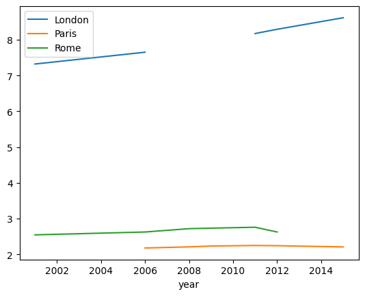

```python
census.plot()
```

The label on the x-axis is taken directly from the column name that we made into the index, `"year"`. Let's make it have a capital letter at the start by passing the `xlabel` argument to `plot`:

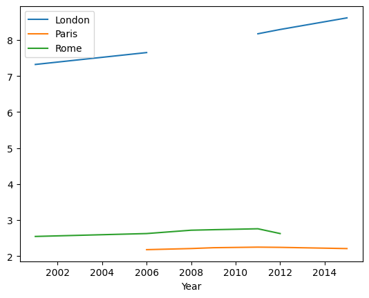

```python
census.plot(
    xlabel="Year",
)
```

And then also set a y-axis label in a similar way:

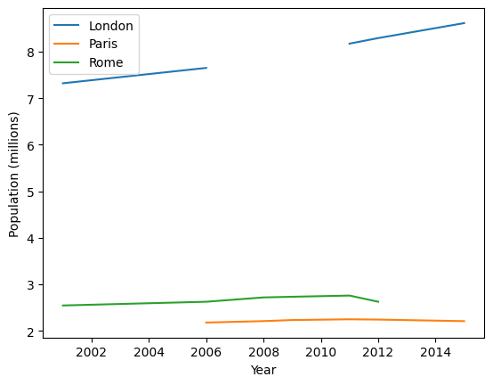

```python
census.plot(
    xlabel="Year",
    ylabel="Population (millions)",
)
```

The y-axis currently starts around 2 which makes the difference between London and the other cities look greater than it actually is. It's usually a good idea to set your y-axis to start at zero. We can pass a tuple `(0, None)` to the `ylim` argument which tells the y-axis to start at `0` and the `None` tells it to use the default scale for the upper bound:

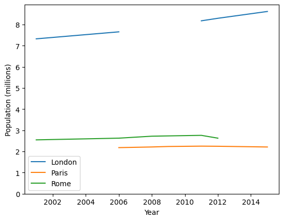

```python
census.plot(
    xlabel="Year",
    ylabel="Population (millions)",
    ylim=(0, None),
)
```

This is now a perfectly functional graph. All we might want to do now is to play with the aesthetics a little. Using [seaborn](https://seaborn.pydata.org) we can use their theme which can use nicer fonts and colours:

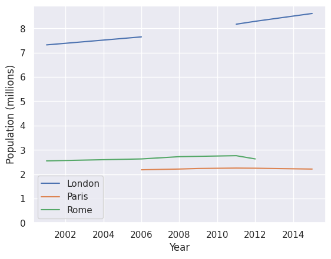

```python
import seaborn as sns

sns.set_theme()

census.plot(
    xlabel="Year",
    ylabel="Population (millions)",
    ylim=(0, None),
)
```

If we want a white background again, we can specify the seaborn style with `sns.set_style`:

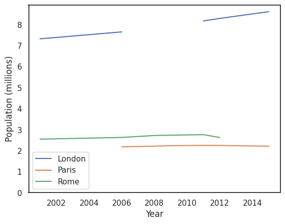

```python
sns.set_style("white")

census.plot(
    xlabel="Year",
    ylabel="Population (millions)",
    ylim=(0, None),
)
```

Or, if we want, we can use seaborn directly as the plotting tool using seaborn's `sns.relplot`:

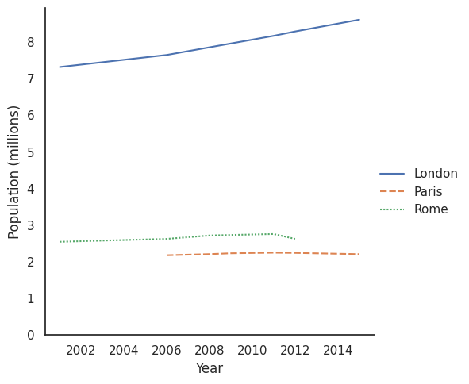

```python
sns.relplot(data=census, kind="line").set(
    xlabel="Year",
    ylabel="Population (millions)",
    ylim=(0, None),
)
```